# Exploring health with 2015 Victorian local government areas (LGA) statistical profiles

# Introduction

An exploratory data analysis to find correlation between segments of the Victorian population and issues concerning health

- Potential predictors that cause ill health.
- Identify in which areas these issues occur
- Discuss possible solutions to health problems which may reduce health costs

# The data

Data collected by the Department of Health and Human services from local governemt areas that cover population, housing, health statuses and many other metrics. 79 total LGAs.

https://www2.health.vic.gov.au/about/reporting-planning-data/gis-and-planning-products/geographical-profiles

- 404 variables
- 80 rows in total
- Excel sheet with tabs that divide the data by LGA, Area, Region and division
- Using ‘LGA’ tab of the original excel file

# Pre-processing

- Each tab of interest was converted to a csv file for easy analysis in R
- Combined data with Victorian spatial data for map visualisation (https://www.data.vic.gov.au/data/dataset/vicmap-lite)
- Many of the variables that are meant to represent numerical figures were cleaned and converted to numeric fields
- LGA Name field cleaned for merging with spatial data

# Factors affecting health and health costs:

- Social housing
- Low income families with children
- Low proficiency in English
- Level of education

# Social housing

- There is a medium correlation between Social housing residency and increased notifications of Chlamydia
- Both are more highly correlated with high crime areas

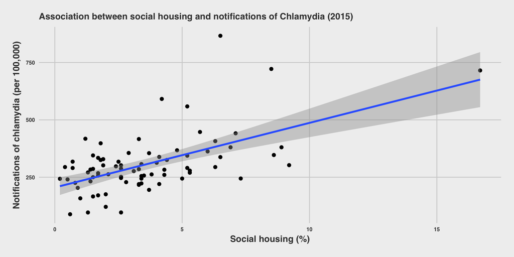

# Social housing area breakdown

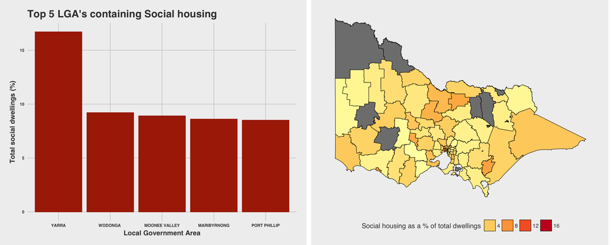

# Low income families with children

- Low income families could be perceived to have heavy financial burdens
- Possibly leads to health taking a lower priority

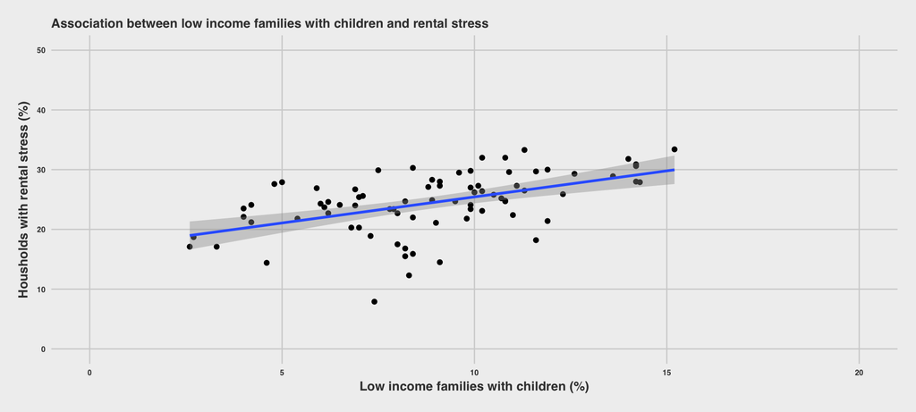

# Low income families with children (contd.)

- Strong negative correlation between lower income families indicates lack of private health insurance
- Positive correlation between low income families and delaying health consultations

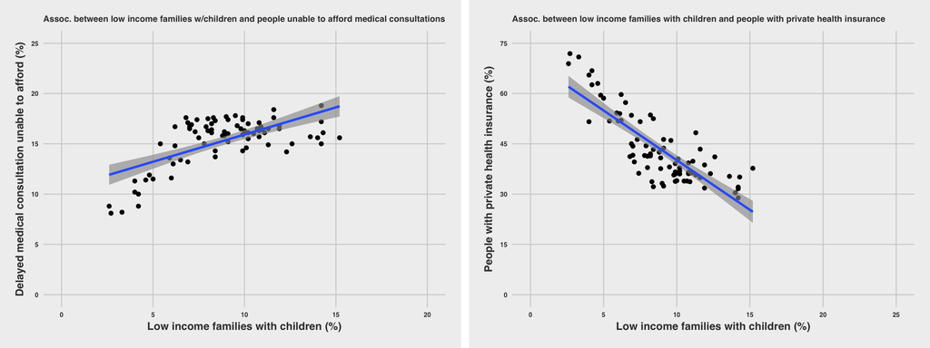

# Low income families with children area breakdown

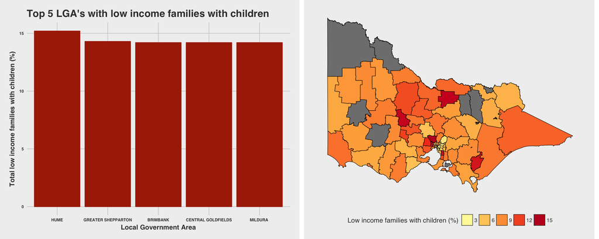

# Low profeciency in English

- Possible signal of immigrants and people new to the country
- They might have a harder time knowing how to access health services
- Potentially lack of vaccination programs in the country they came from

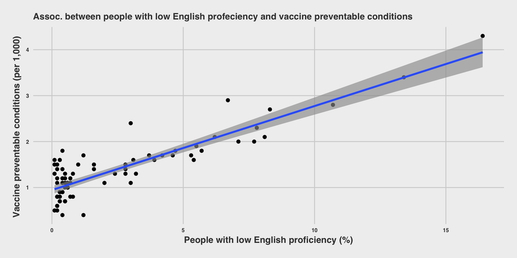

# Low proficiency in English area breakdown

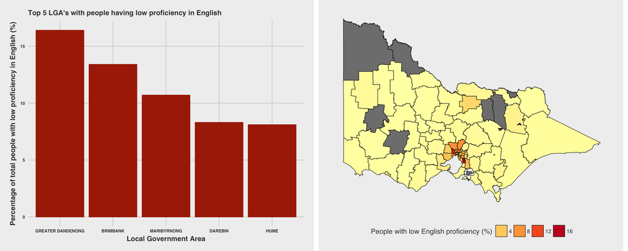

# Level of education

- A correlation between people not having finished year 12 and being treated for preventable health issues
- This could be seen as a factor that is increasing the cost of healthcare
- If issues can be prevented before they need hospitalisation, the government could potentially provide more facilties for issues that are not preventable

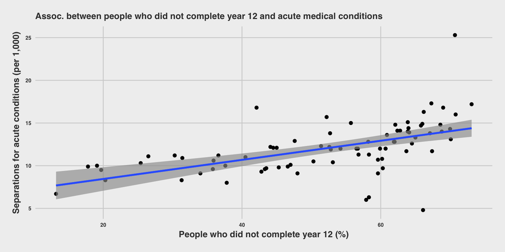

# People who did not complete year 12 area breakdown

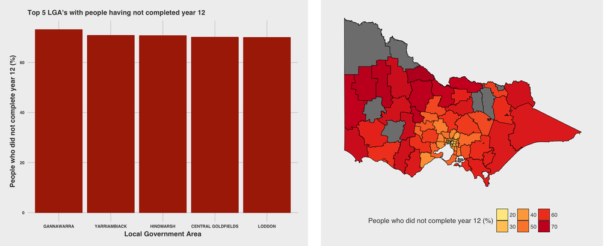

# Conclusion and Discussion

What are some ideas to mitigate these health concerns

- Social housing:
  - Free contraceptive vending machine inside of social dwellings
  - Simple awareness, in the form of an event around the social dwellings
- Low income families
  - Conduct further in-depth surveys to see what health issues are people unable to solve
  - Use survey results to extend eligibility criteria of people who can be bulk billed
  - Delay payment for immediate consultation (interest free)
- English Proficiency
  - Community engagement to help new comers in knowing how to access services
  - Provide free or subsidiesed vaccines
- Education
  - Increase awareness in how to identitfy and prevent medical issues before hospitalisation is needed